# **Data Engineering for Data Science - Week 10**

[figure not shown]

## **Introduction to Cloud Computing**

(C) Taufik Sutanto

# **Outline**

## I. Theoretical Foundations

- Cloud Paradigms: Comparative analysis of IaaS, PaaS, and SaaS models.
- Operational Principles: Examination of scalability, elasticity, and the shared responsibility model.

## II. Infrastructure & Governance

- Resource Hierarchy: Navigating the organizational structure from Projects to Global Regions.
- Interface Management: Technical orientation of the GCP Console and Cloud Shell environment.

## III. Analytical Ecosystem

- BigQuery: Implementation of serverless data warehousing and SQL-based analytics.
- Vertex AI: Systematic overview of the machine learning lifecycle and integrated tooling.

## IV. Laboratory Methodology (Credit-Free)

- **Skills Boost**: Execution of hands-on modules utilizing temporary credentials.
- Sandbox Deployment: Facilitating data exploration through the BigQuery free-tier environment.

## V. Synthesis & Evaluation

- Architectural Design: Formulation of a cloud-native data pipeline for predictive modeling.
- Critical Review: Assessment of system constraints and deployment feasibility.

# Cloud Computing?

> “A model for enabling convenient **on-demand network access** to a **shared** pool of **configurable computing resources** that can be rapidly provisioned and released with **minimal** management effort or **service provider interaction** ” [US National Institute of Standards and Technology (NIST)]

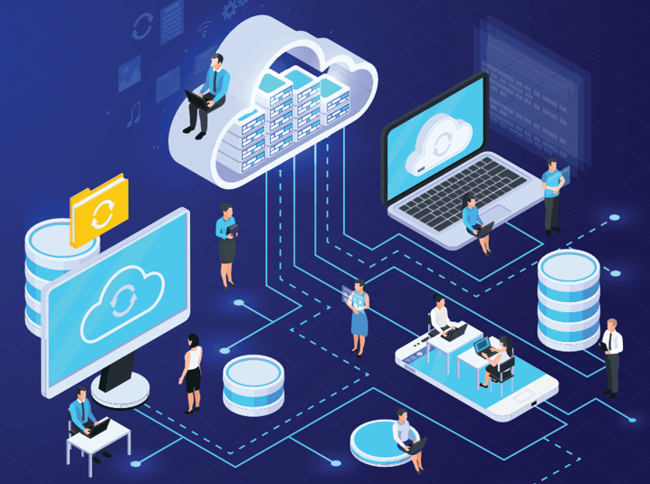

[figure not shown]

Cloud computing is a modern approach to delivering computing services through the internet. Instead of purchasing and maintaining physical computer hardware and software independently, users can access computing resources remotely whenever needed. These resources may include servers, storage systems, databases, networking tools, software applications, and artificial intelligence services.

Cloud computing has become one of the foundational technologies of the digital era because it allows organizations and individuals to use powerful computing capabilities without owning expensive infrastructure.

# When Should Cloud Computing Be Used?

- When computational, memory, and/or storage requirements are uncertain or highly dynamic (*elastic*).
- When the goal is to minimize infrastructure maintenance and focus primarily on application development and deployment.
- When ensuring system availability, low latency, and robustness for users is essential.
- When rapid application development and deployment are required.
- When there is a desire to reduce the complexity associated with managing network and infrastructure security configurations.

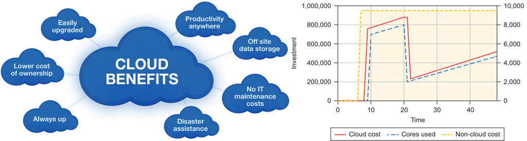

# When (Public) Cloud Is Less Suitable

- No stable and sufficient funding for Cloud operations.
- Stable long-term computer resource requirements.
- Confidential data that regulations prohibit from being uploaded to the cloud.
- Unreliable internet connections for application users.
- Vendor lock-in ... high dependency on providers.
- Limited system customization.
- Of course, hybrid approaches are possible
- For example, combining simple web hosting, local computing power, and/or VPS.

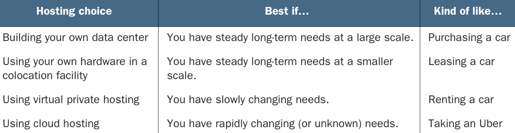

# Compliance with Industry Regulations: Be Careful with Data Regulations of using Cloud

- General Data Protection Regulation (GDPR), a European Union privacy protection regulation
- Payment Card Industry Data Standard (PCI), a data protection regulation for credit card processing
- Health Insurance Portability and Accountability Act (HIPAA), a healthcare regulation
- Children’s Online Privacy Protection Act (COPPA), a privacy regulation
- Sarbanes-Oxley Act (SOX), a financial reporting regulation

# Characteristics of Cloud Computing

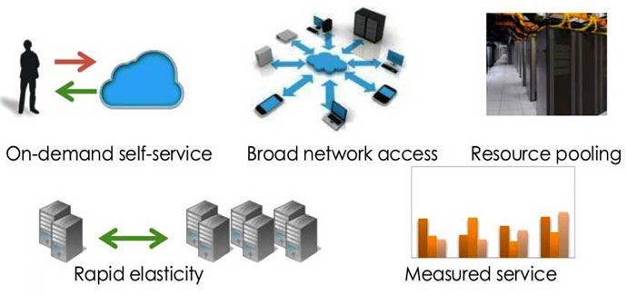

- **On-demand self-service**: No human interaction required (e.g., customer service)
- **Broad network access**: Accessible from various heterogeneous client/user platforms (e.g., mobile phones, tablets, laptops, IoT devices, and workstations).
- **Resource pooling**: Cloud provider resources are pooled and shared among multiple users.
- **Rapid elasticity**: Resources can be scaled up or down quickly according to demand.
- **Measured service**: Resource usage can be monitored, controlled, and billed automatically.

# **Theoretical Foundations of Cloud Computing: Virtualization**

Virtualization is the process of creating virtual versions of computing resources such as servers, storage devices, or operating systems. A single physical computer can be divided into multiple virtual machines (VMs), each functioning as an independent computer.

### Virtualization enables cloud providers to:

- Maximize hardware utilization
- Reduce operational costs
- Provide flexible resource allocation
- Rapidly deploy services

[figure not shown]

## Elasticity and Scalability

- **Scalability** refers to the ability of a system to handle increasing workloads by adding resources.
- **Elasticity** refers to the automatic adjustment of resources according to demand.
- **Importance**: These characteristics are among the most significant advantages of cloud computing because they allow organizations to efficiently manage changing workloads.

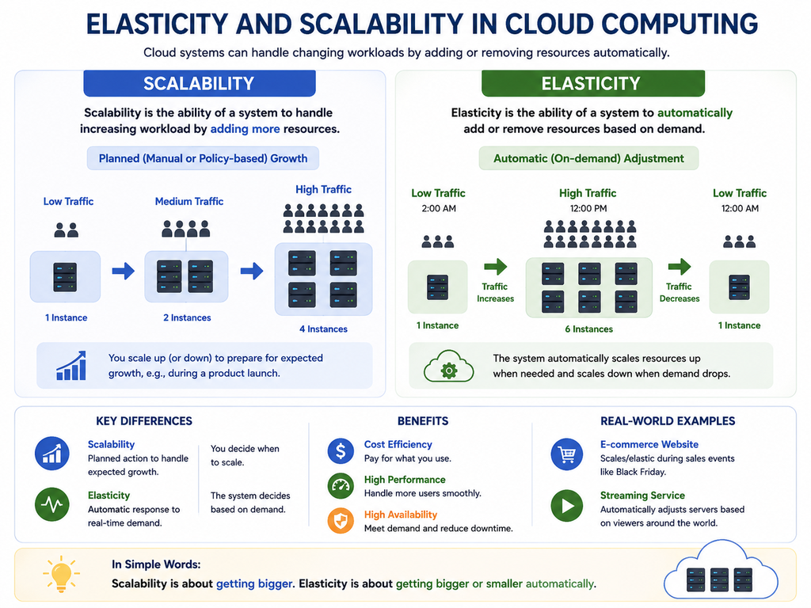

# Cloud Types

- **Private Cloud**: Organizations/Institutions are fully responsible for managing and operating their computing infrastructure services. The machines in a Private Cloud may be located on-premises or hosted by a cloud provider but directed into a private network.
- **Public Cloud**: Cloud service providers offer their computing infrastructure and products for public use by other companies and individuals via the internet.

[figure not shown]

- TCO: Total Cost Ownership

# Public Cloud Providers

[figure not shown]

# Cloud Service Paradigms

[figure not shown]

## Software as A Service (SaaS)

- Examples: Google Docs, Dropbox, Onedrive, Gdrive, Slack, Skype, Zoom, Microsoft Office 365
- Software is not downloaded and installed; it requires an active internet connection.
- Advantages: Companies are not burdened with installation, management, maintenance, etc.
- Disadvantages: Vendor lock-in, performance, data security.
- Applicability: Suitable for small startups, short-term projects, and temporary-use applications.

## Platform as A Service (PaaS)

- Provides a platform/environment for application development and deployment.
- Developers focus on application development without managing infrastructure.

## Infrastructure as A Service (IaaS)

- Provides virtualized computing infrastructure.
- Users manage operating systems, applications, and configurations independently.

# Comparative Analysis of IaaS, PaaS, and SaaS

| Aspect | IaaS | PaaS | SaaS |
| --- | --- | --- | --- |
| Main Purpose | Provide infrastructure | Provide development platform | Provide ready-to-use software |
| User Control | Highest | Moderate | Lowest |
| Technical Skill Required | High | Moderate | Low |
| Infrastructure Management | User manages many components | Provider manages infrastructure | Provider manages everything |
| Flexibility | Very flexible | Moderately flexible | Limited flexibility |
| Ease of Use | Complex | Easier | Easiest |
| Typical Users | System administrators, IT engineers | Software developers | General users |
| Example Services | Amazon EC2 | Google App Engine | Google Docs |

# Responsibility Comparison

| Component | IaaS | PaaS | SaaS |
| --- | --- | --- | --- |
| Applications | User | User | Provider |
| Data | User | User | Provider/User |
| Runtime | User | Provider | Provider |
| Operating System | User | Provider | Provider |
| Virtualization | Provider | Provider | Provider |
| Servers | Provider | Provider | Provider |
| Networking | Provider | Provider | Provider |

# Cloud Terminology & Profile

[figure not shown]

# Cloud Architecture: An Application Usually Uses Multiple Cloud Services

[figure not shown]

# Cloud Cost

[figure not shown]

# Google Cloud Platform - GCP

- https://console.cloud.google.com/apis/library

[figure not shown]

# Important (GCP) Links

- https://cloud.google.com/free
- https://www.skills.google/
- https://cloud.google.com/docs
- https://developers.google.com/apis-explorer
- https://cloud.google.com/learn/training

[figure not shown]

```python
# Python Modules for GCP
!pip install --upgrade google-api-python-client google-auth-httplib2 google-auth-oauthlib --q
!pip install --upgrade google-cloud-storage --q
!pip install --upgrade google-cloud-language --q
!pip install  --upgrade google-cloud-vision --q
!pip install  --upgrade google-cloud-dialogflow --q
"Done"
```

```
'Done'
```

# **Lecture Agenda (Beginning Next Week)**

1. The evaluation for Topic C will be conducted through active group presentations.
2. The class will be divided into three groups.
3. Each group will deliver a 45-minute presentation each week on the use of Google Cloud, followed by a 15-minute class discussion session.
4. Both the presentation quality and class participation (particularly during discussions) will be assessed.
5. Students are encouraged to employ any form of innovation or creativity in explaining the material.
6. The lecturer will subsequently provide further explanation on the same topic after the student presentations.
7. The topics to be covered include:
   - **Compute Engine** and **Cloud Storage (GCS)** in GCP
   - Google **BigQuery**
   - Google **Vertex AI**

## **End of Module**

[figure not shown]